# HW 5: Jenil Kansara

# Exerise 1

## 1.1

```python
import pandas as pd
import numpy as np
```

```python
df = pd.read_csv('Food_Inspection.csv')
```

```python
pd.DataFrame(df['Category'].unique())
```

|  | 0 |
| --- | --- |
| 0 | Restaurant |
| 1 | Market |
| 2 | Caterer |
| 3 | Non-Profit |
| 4 | Public School- Other |
| 5 | NaN |
| 6 | Public School- Elementary |
| 7 | Hospital |
| 8 | Public School- Middle |
| 9 | Assisted Living |
| 10 | Private School |
| 11 | Nursing Home |
| 12 | Public School- High |
| 13 | Carry Out |
| 14 | Farmers Market |
| 15 | Snack Bar |
| 16 | Institution |
| 17 | Excluded Organization |
| 18 | Seasonal |
| 19 | Mobile Unit |

Here 'Restaurant' and 'Snack Bar' represents a restaurant.

```python
df['RestDummy']=0
df.loc[(df['Category'] == 'Restaurant') | (df['Category'] == 'Snack Bar') , 'RestDummy'] = 1
```

## 1.2

```python
df['Inspection Date']=pd.to_datetime(df['Inspection Date'])
```

```python
df['Year']=df['Inspection Date'].dt.year
df['Month']=df['Inspection Date'].dt.month
df['YearMonth']=df['Inspection Date'].dt.to_period('m')
```

```python
df
```

|  | Establishment ID | Name | Address 1 | Address 2 | City | Zip | Inspection Date | Inspection Results | Food from Approved Source (C) | Food Protected from Contamination (C) | ... | Owner | Category | Type | Latitude | Longitude | Location | RestDummy | Year | Month | YearMonth |
| --- | --- | --- | --- | --- | --- | --- | --- | --- | --- | --- | --- | --- | --- | --- | --- | --- | --- | --- | --- | --- | --- |
| 0 | 18628 | SUBWAY #22916 | 12193 DARNESTOWN RD. | NaN | GAITHERSBURG | 20878 | 2018-12-19 | No Critical Violations Noted | In Compliance | In Compliance | ... | P. N. ENTERPRISES, LLC | Restaurant | Food | 39.1179 | -77.2524 | (39.1179, -77.2524) | 1 | 2018 | 12 | 2018-12 |
| 1 | 1059 | GIANT FOOD #0192 | 18250 FLOWER HILL WAY | NaN | GAITHERSBURG | 20879 | 2018-12-19 | Critical Violations Corrected | In Compliance | In Compliance | ... | GIANT OF MARYLAND, LLC | Market | Food | 39.1551 | -77.1659 | (39.1551, -77.1659) | 0 | 2018 | 12 | 2018-12 |
| 2 | 20933 | PIZZA BOLIS | 7831 EASTERN AVE. | NaN | SILVER SPRING | 20910 | 2018-12-19 | No Critical Violations Noted | In Compliance | In Compliance | ... | K.M.MG INC | Restaurant | Food | 38.9853 | -77.0273 | (38.9853, -77.0273) | 1 | 2018 | 12 | 2018-12 |
| 3 | 22217 | GREENE TURTLE | 18101 TOWN CENTER DR | NaN | OLNEY | 20832 | 2017-12-13 | No Critical Violations Noted | In Compliance | In Compliance | ... | OLNEY GT, LLC. | Restaurant | Food | 39.1519 | -77.0619 | (39.1519, -77.0619) | 1 | 2017 | 12 | 2017-12 |
| 4 | 28408 | CRAVE | 7101 DEMOCRACY BLVD | SPACE #FC | BETHESDA | 20817 | 2018-12-13 | No Critical Violations Noted | In Compliance | In Compliance | ... | CRAVE RESTAURANT BETHESDA LLC | Restaurant | Food | 39.0221 | -77.1471 | (39.0221, -77.1471) | 1 | 2018 | 12 | 2018-12 |
| 5 | 28011 | FIRST WATCH RESTAURANT #139 | 802 MUDDY BRANCH RD | NaN | GAITHERSBURG | 20878 | 2018-12-19 | Critical Violations Corrected | In Compliance | In Compliance | ... | FIRST WATCH RESTAURANTS, INC | Restaurant | Food | 39.1137 | -77.2167 | (39.1137, -77.2167) | 1 | 2018 | 12 | 2018-12 |
| 6 | 27427 | MIRCH MASALA GRILL | 7101 DEMOCRACY BLVD | SPACE #2340 | BETHESDA | 20817 | 2018-12-18 | Critical Violations Corrected | In Compliance | In Compliance | ... | SHIVA DELIGHT INC | Restaurant | Food | 39.0250 | -77.1483 | (39.025, -77.1483) | 1 | 2018 | 12 | 2018-12 |
| 7 | 22419 | APPLEBEE'S | 21048 FREDERICK RD. | NaN | GERMANTOWN | 20876 | 2017-12-12 | No Critical Violations Noted | In Compliance | In Compliance | ... | POTOMAC FAMILY DINING GROUP OPERATING COMPANY | Restaurant | Food | 39.2018 | -77.2460 | (39.2018, -77.246) | 1 | 2017 | 12 | 2017-12 |
| 8 | 21231 | SIRIWAN THAI RESTAURANT | 736 CLOVERLY ST. | NaN | SILVER SPRING | 20905 | 2017-12-12 | Critical Violations Corrected | In Compliance | In Compliance | ... | SIRIWAN THAI RESTAURANT, INC. | Restaurant | Food | 39.1095 | -76.9954 | (39.1095, -76.9954) | 1 | 2017 | 12 | 2017-12 |
| 9 | 30673 | DOG HAUS | 7704 WOODMONT AVE | NaN | BETHESDA | 20814 | 2018-12-18 | No Critical Violations Noted | In Compliance | In Compliance | ... | DOG HAUS | Restaurant | Food | 38.9866 | -77.0968 | (38.9866, -77.0968) | 1 | 2018 | 12 | 2018-12 |
| 10 | 20921 | SUBWAY #18137 | 18137 TOWN CENTER DR. | NaN | OLNEY | 20832 | 2017-12-12 | No Critical Violations Noted | In Compliance | In Compliance | ... | DELIGHTS FOODS, INC | Restaurant | Food | 39.1528 | -77.0613 | (39.1528, -77.0613) | 1 | 2017 | 12 | 2017-12 |
| 11 | 27452 | CHIPOTLE MEXICAN GRILL #2055 | 11160 VEIRS MILL RD | SPACE P208C | SILVER SPRING | 20902 | 2017-12-13 | No Critical Violations Noted | In Compliance | In Compliance | ... | CHOPOTLE MEXICAN GRILL OF COLORADO LLC | Restaurant | Food | 39.0370 | -77.0539 | (39.037, -77.0539) | 1 | 2017 | 12 | 2017-12 |
| 12 | 2097 | RITE AID #04597 | 1411 EAST-WEST HWY. | NaN | SILVER SPRING | 20910 | 2017-12-13 | No Critical Violations Noted | In Compliance | In Compliance | ... | RITE AID OF MARYLAND, INC. | Market | Food | 38.9946 | -77.0330 | (38.9946, -77.033) | 0 | 2017 | 12 | 2017-12 |
| 13 | 19393 | NATRAJ RESTAURANT CATERER | 403 E. DIAMOND AVE | NaN | GAITHERSBURG | 20877 | 2018-12-18 | Critical Violations Corrected | In Compliance | Out of Compliance | ... | JANAKARORA ASHWANIRORA | Caterer | Food | 39.1419 | -77.1904 | (39.1419, -77.1904) | 0 | 2018 | 12 | 2018-12 |
| 14 | 1264 | ISKCON CHURCH | 10310 OAKLYN RD. | NaN | POTOMAC | 20854 | 2018-12-13 | Critical Violations Corrected | In Compliance | Out of Compliance | ... | ISKCON OF D. C. INC. | Restaurant | Food | 39.0026 | -77.2132 | (39.0026, -77.2132) | 1 | 2018 | 12 | 2018-12 |
| 15 | 23559 | DIPPIN DOTS | 701 RUSSELL AVE | F 205 | GAITHERSBURG | 20877 | 2018-12-19 | No Critical Violations Noted | In Compliance | In Compliance | ... | MEHDI TRADES LLC | Restaurant | Food | 39.1534 | -77.2040 | (39.1534, -77.204) | 1 | 2018 | 12 | 2018-12 |
| 16 | 27538 | GREGORIO'S TRATTORIA | 7745 TUCKERMAN LN. | NaN | POTOMAC | 20854 | 2018-12-18 | Critical Violations Corrected | In Compliance | In Compliance | ... | GREGORIO'S LLC | Restaurant | Food | 39.0406 | -77.1554 | (39.0406, -77.1554) | 1 | 2018 | 12 | 2018-12 |
| 17 | 33210 | KEY INDGREDIENTS CATERING | 7840 BEECHCRAFT AVE | NaN | GAITHERSBURG | 20879 | 2018-12-19 | No Critical Violations Noted | In Compliance | In Compliance | ... | HUMBERTO MENDEZ / JAVIER ZENOR | Caterer | Food | 39.1623 | -77.1614 | (39.1623, -77.1614) | 0 | 2018 | 12 | 2018-12 |
| 18 | 28847 | WHEATON VOLUNTEER RESCUE SQUAD | 2400 ARCOLA AVE | NaN | SILVER SPRING | 20902 | 2017-12-12 | No Critical Violations Noted | In Compliance | In Compliance | ... | WHEATON VOL RESCUE SQUAD | Non-Profit | Food | 39.0467 | -77.0515 | (39.0467, -77.0515) | 0 | 2017 | 12 | 2017-12 |
| 19 | 30796 | CARAVAN DELI & KABAB | 615 S. FREDERICK AVE | NaN | GAITHERSBURG | 20877 | 2018-12-18 | Critical Violations Corrected | In Compliance | In Compliance | ... | ALI DARDASHTI | Restaurant | Food | 39.1293 | -77.1858 | (39.1293, -77.1858) | 1 | 2018 | 12 | 2018-12 |
| 20 | 20989 | EUREST DINING SERVICES | 5260 WESTERN AVE. | NaN | CHEVY CHASE | 20815 | 2018-12-19 | Critical Violations Corrected | In Compliance | In Compliance | ... | COMPASS GROUP USA, INC. | Restaurant | Food | 38.9609 | -77.0903 | (38.9609, -77.0903) | 1 | 2018 | 12 | 2018-12 |
| 21 | 20138 | RITA'S #715 | 701 RUSSELL AVE | D129 | GAITHERSBURG | 20878 | 2018-12-19 | No Critical Violations Noted | In Compliance | In Compliance | ... | ICETACULAR, LLC. | Market | Food | 39.1534 | -77.2040 | (39.1534, -77.204) | 0 | 2018 | 12 | 2018-12 |
| 22 | 2177 | INTIPUQUENO RESTAURANT | 2504 ENNALLS AVE. | NaN | WHEATON | 20902 | 2017-12-12 | No Critical Violations Noted | In Compliance | In Compliance | ... | INTIPUQUENO, LLC | Restaurant | Food | 39.0396 | -77.0530 | (39.0396, -77.053) | 1 | 2017 | 12 | 2017-12 |
| 23 | 28818 | MCPS FOOD SERVICES TEST/CATERING KITCHEN | 8401 TURKEY THICKET DR | NaN | GAITHERSBURG | 20879 | 2017-12-12 | No Critical Violations Noted | In Compliance | In Compliance | ... | MCPS | Public School- Other | Food | 39.1752 | -77.1731 | (39.1752, -77.1731) | 0 | 2017 | 12 | 2017-12 |
| 24 | 26642 | AZUL BAR & GRILL | 18749 - D N. FREDERICK RD | NaN | GAITHERSBURG | 20879 | 2017-12-13 | Critical Violations Corrected | In Compliance | In Compliance | ... | CATALINO VILLATORO | Restaurant | Food | 39.1637 | -77.2255 | (39.1637, -77.2255) | 1 | 2017 | 12 | 2017-12 |
| 25 | 32869 | JASMINE BAKERY AND CAFE | 18503 N. FREDERICK AVE | NaN | GAITHERSBURG | 20879 | 2017-12-13 | No Critical Violations Noted | In Compliance | In Compliance | ... | GHODRATOLLAH AZIZI | Restaurant | Food | 39.1615 | -77.2200 | (39.1615, -77.22) | 1 | 2017 | 12 | 2017-12 |
| 26 | 23114 | SPRINGBROOK H.S. ATHLETICS CONCESSIONS | 201 VALLEY BROOK DR. | NaN | SILVER SPRING | 20904 | 2018-12-17 | Critical Violations Corrected | In Compliance | In Compliance | ... | SPRINGBROOK H.S. ATHLETICS CONCESSIONS | Market | Food | 39.0583 | -77.0058 | (39.0583, -77.0058) | 0 | 2018 | 12 | 2018-12 |
| 27 | 20923 | DELICIOUS GOURMET | 7840 BEECHCRAFT AVE. | NaN | GAITHERSBURG | 20879 | 2018-12-19 | Critical Violations Corrected | In Compliance | In Compliance | ... | MAHMOUD ABUL HAWA | NaN | Food | 39.1621 | -77.1616 | (39.1621, -77.1616) | 0 | 2018 | 12 | 2018-12 |
| 28 | 386 | BURNT MILLS ELEMENTARY | 11211 CHILDS ST. | NaN | SILVER SPRING | 20901 | 2018-12-17 | Critical Violations Corrected | In Compliance | In Compliance | ... | MONTGOMERY COUNTY PUBLIC SCHOOLS | Public School- Elementary | Food | 39.0394 | -77.0013 | (39.0394, -77.0013) | 0 | 2018 | 12 | 2018-12 |
| 29 | 2476 | TASTE OF EUROPE | 630 QUINCE ORCHARD RD. | NaN | GAITHERSBURG | 20878 | 2018-12-18 | No Critical Violations Noted | In Compliance | In Compliance | ... | TASTE OF EUROPE, INC. | Market | Food | 39.1413 | -77.2239 | (39.1413, -77.2239) | 0 | 2018 | 12 | 2018-12 |
| ... | ... | ... | ... | ... | ... | ... | ... | ... | ... | ... | ... | ... | ... | ... | ... | ... | ... | ... | ... | ... | ... |
| 13671 | 2689 | WOOD ACRES ELEMENTARY | 5800 CROMWELL DR. | NaN | BETHESDA | 20816 | 2017-11-14 | No Critical Violations Noted | In Compliance | In Compliance | ... | MONTGOMERY COUNTY PUBLIC SCHOOLS | Public School- Elementary | Food | 38.9677 | -77.1186 | (38.9677, -77.1186) | 0 | 2017 | 11 | 2017-11 |
| 13672 | 18849 | PRALINE BAKERY | 4611-O SANGAMORE RD. | NaN | BETHESDA | 20816 | 2018-12-18 | Critical Violations Corrected | In Compliance | In Compliance | ... | PRALINE BAKERY, LLC | Restaurant | Food | 38.9500 | -77.1194 | (38.95, -77.1194) | 1 | 2018 | 12 | 2018-12 |
| 13673 | 30661 | SILVER CREEK MIDDLE SCHOOL | 3701 SAUL RD | NaN | KENSINGTON | 20895 | 2018-12-18 | No Critical Violations Noted | In Compliance | In Compliance | ... | MONTGOMERY COUNTY PUBLIC SCHOOLS | Public School- Middle | Food | 39.0159 | -77.0750 | (39.0159, -77.075) | 0 | 2018 | 12 | 2018-12 |
| 13674 | 1800 | OLD ANGLER'S INN | 10801 MAC ARTHUR BLVD. | NaN | POTOMAC | 20854 | 2018-06-26 | No Critical Violations Noted | In Compliance | In Compliance | ... | MARYLAND CATERING CO., INC. | Restaurant | Food | 38.9825 | -77.2265 | (38.9825, -77.2265) | 1 | 2018 | 6 | 2018-06 |
| 13675 | 30077 | NEW VILLAGE | 11540-11542 MIDDLEBROOK RD | NaN | GERMANTOWN | 20876 | 2018-01-18 | No Critical Violations Noted | In Compliance | In Compliance | ... | 58 UNITY LLC | Restaurant | Food | 39.1795 | -77.2396 | (39.1795, -77.2396) | 1 | 2018 | 1 | 2018-01 |
| 13676 | 19498 | DON POLLO OF BETHESDA | 7007-7009 WISCONSIN AVE. | NaN | CHEVY CHASE | 20815 | 2018-12-17 | Critical Violations Corrected | In Compliance | In Compliance | ... | DANIEL GODOY | Restaurant | Food | 38.9796 | -77.0916 | (38.9796, -77.0916) | 1 | 2018 | 12 | 2018-12 |
| 13677 | 795 | DUFIEF ELEMENTARY | 15001 DUFIEF DR. | NaN | GAITHERSBURG | 20878 | 2018-04-04 | No Critical Violations Noted | In Compliance | In Compliance | ... | MONTGOMERY COUNTY PUBLIC SCHOOLS | Public School- Elementary | Food | 39.1022 | -77.2376 | (39.1022, -77.2376) | 0 | 2018 | 4 | 2018-04 |
| 13678 | 28 | 7-ELEVEN #11727 | 5114 RIVER RD | NaN | BETHESDA | 20816 | 2017-10-05 | No Critical Violations Noted | In Compliance | In Compliance | ... | C S MANAGEMENT, INC./7-ELEVEN | Market | Food | 38.9635 | -77.1025 | (38.9635, -77.1025) | 0 | 2017 | 10 | 2017-10 |
| 13679 | 27355 | POLLERIA 3 AMIGOS II | 8736 PINEY BRANCH RD | NaN | SILVER SPRING | 20901 | 2018-12-18 | Critical Violations Corrected | In Compliance | In Compliance | ... | POLLERIA 3 AMIGOS II INC | Restaurant | Food | 38.9995 | -76.9965 | (38.9995, -76.9965) | 1 | 2018 | 12 | 2018-12 |
| 13680 | 20296 | LEDO'S PIZZA - DERWOOD | 7213 MUNCASTER MILL RD | NaN | DERWOOD | 20855 | 2018-12-18 | No Critical Violations Noted | In Compliance | In Compliance | ... | BOGEY ENTERPRISES | Restaurant | Food | 39.1464 | -77.1446 | (39.1464, -77.1446) | 1 | 2018 | 12 | 2018-12 |
| 13681 | 29392 | INTER-DENOMINATIONAL CHURCH OF GOD | 19201 WOODFIELD RD | NaN | GAITHERSBURG | 20879 | 2018-12-18 | No Critical Violations Noted | In Compliance | In Compliance | ... | INTER-DENOMINATIONAL CHURCH OF GOD | Restaurant | Food | 39.1707 | -77.1527 | (39.1707, -77.1527) | 1 | 2018 | 12 | 2018-12 |
| 13682 | 28656 | ISLAMIC SOCIETY OF GERMANTOWN | 19825 BLUNT RD | NaN | GERMANTOWN | 20876 | 2017-12-07 | No Critical Violations Noted | In Compliance | In Compliance | ... | ISLAMIC SOCIETY OF GERMANTOWN | Restaurant | Food | 39.1811 | -77.2359 | (39.1811, -77.2359) | 1 | 2017 | 12 | 2017-12 |
| 13683 | 30077 | NEW VILLAGE | 11540-11542 MIDDLEBROOK RD | NaN | GERMANTOWN | 20876 | 2018-01-09 | No Critical Violations Noted | In Compliance | In Compliance | ... | 58 UNITY LLC | Restaurant | Food | 39.1795 | -77.2396 | (39.1795, -77.2396) | 1 | 2018 | 1 | 2018-01 |
| 13684 | 33268 | 7-ELEVEN #28840J | 7305 MAC ARTHUR BLVD | NaN | BETHESDA | 20816 | 2018-12-18 | No Critical Violations Noted | In Compliance | In Compliance | ... | 7-ELEVEN INC | Market | Food | 38.9694 | -77.1387 | (38.9694, -77.1387) | 0 | 2018 | 12 | 2018-12 |
| 13685 | 20892 | DUNKIN DONUTS | 865-A ROCKVILLE PIKE | NaN | ROCKVILLE | 20852 | 2018-12-18 | No Critical Violations Noted | In Compliance | In Compliance | ... | W DONUT OPERATING, LLC. | NaN | Food | 39.0752 | -77.1378 | (39.0752, -77.1378) | 0 | 2018 | 12 | 2018-12 |
| 13686 | 742 | DIAMOND ELEMENTARY | 4 MARQUIS DR. | NaN | GAITHERSBURG | 20878 | 2018-04-03 | No Critical Violations Noted | In Compliance | In Compliance | ... | MONTGOMERY COUNTY PUBLIC SCHOOLS | Public School- Elementary | Food | 39.1357 | -77.2389 | (39.1357, -77.2389) | 0 | 2018 | 4 | 2018-04 |
| 13687 | 26685 | FLIK INTERNATIONAL CORP @ MEDIMMUNE | 950 WIND RIVER LANE | NaN | GAITHERSBURG | 20878 | 2018-06-07 | No Critical Violations Noted | In Compliance | In Compliance | ... | FLIK INTERNATIONAL CORP | Restaurant | Food | 39.1299 | -77.2326 | (39.1299, -77.2326) | 1 | 2018 | 6 | 2018-06 |
| 13688 | 359 | BROWN STATION ELEMENTARY | 851 QUINCE ORCHARD BLVD. | NaN | GAITHERSBURG | 20878 | 2017-10-23 | No Critical Violations Noted | In Compliance | In Compliance | ... | MONTGOMERY COUNTY PUBLIC SCHOOLS | Public School- Elementary | Food | 39.1388 | -77.2307 | (39.1388, -77.2307) | 0 | 2017 | 10 | 2017-10 |
| 13689 | 27945 | FENTON STREET SERVICE STATION | 8301 FENTON ST | NaN | SILVER SPRING | 20910 | 2018-12-17 | No Critical Violations Noted | In Compliance | In Compliance | ... | FENTON SERVICE STATION, INC | Restaurant | Food | 38.9934 | -77.0237 | (38.9934, -77.0237) | 1 | 2018 | 12 | 2018-12 |
| 13690 | 26646 | 7-ELEVEN #36460A | 405-D N FREDERICK RD | NaN | GAITHERSBURG | 20877 | 2018-12-18 | No Critical Violations Noted | In Compliance | In Compliance | ... | ABE & NIKI, INC | Market | Food | 39.1464 | -77.2040 | (39.1464, -77.204) | 0 | 2018 | 12 | 2018-12 |
| 13691 | 29545 | CASABLANCO SUNOCO | 8875 PINEY BRANCH RD | NaN | SILVER SPRING | 20903 | 2018-12-18 | Critical Violations Corrected | In Compliance | In Compliance | ... | EJRA INC | Market | Food | 38.9995 | -76.9910 | (38.9995, -76.991) | 0 | 2018 | 12 | 2018-12 |
| 13692 | 30543 | ADDIS BEER & WINE | 730 SLIGO AVE | NaN | SILVER SPRING | 20910 | 2018-12-17 | No Critical Violations Noted | In Compliance | In Compliance | ... | HOT INC | Restaurant | Food | 38.9899 | -77.0194 | (38.9899, -77.0194) | 1 | 2018 | 12 | 2018-12 |
| 13693 | 30024 | FUDDRUCKERS SILVER SPRING | 819 ELLSWORTH DR | NaN | SILVER SPRING | 20910 | 2018-03-20 | Critical Violations Corrected | In Compliance | In Compliance | ... | P&B ADVENTURES INC | Restaurant | Food | 38.9974 | -77.0253 | (38.9974, -77.0253) | 1 | 2018 | 3 | 2018-03 |
| 13694 | 30712 | YARD HOUSE #8380 | 211 RIO BLVD | NaN | GAITHERSBURG | 20884 | 2018-11-09 | No Critical Violations Noted | In Compliance | In Compliance | ... | GMR MONTGOMERY COUNTY INC | Restaurant | Food | 39.1172 | -77.2003 | (39.1172, -77.2003) | 1 | 2018 | 11 | 2018-11 |
| 13695 | 795 | DUFIEF ELEMENTARY | 15001 DUFIEF DR. | NaN | GAITHERSBURG | 20878 | 2017-10-26 | No Critical Violations Noted | In Compliance | In Compliance | ... | MONTGOMERY COUNTY PUBLIC SCHOOLS | Public School- Elementary | Food | 39.1022 | -77.2376 | (39.1022, -77.2376) | 0 | 2017 | 10 | 2017-10 |
| 13696 | 29530 | NOAA GOURMET DELI | 1305 EAST WESY HWY | NaN | SILVER SPRING | 20910 | 2018-12-18 | No Critical Violations Noted | In Compliance | In Compliance | ... | BYOUNG-S OHBKSOH INC | Restaurant | Food | 38.9918 | -77.0300 | (38.9918, -77.03) | 1 | 2018 | 12 | 2018-12 |
| 13697 | 742 | DIAMOND ELEMENTARY | 4 MARQUIS DR. | NaN | GAITHERSBURG | 20878 | 2017-10-10 | No Critical Violations Noted | In Compliance | In Compliance | ... | MONTGOMERY COUNTY PUBLIC SCHOOLS | Public School- Elementary | Food | 39.1357 | -77.2389 | (39.1357, -77.2389) | 0 | 2017 | 10 | 2017-10 |
| 13698 | 1772 | NORTH CHEVY CHASE ELEMENTARY | 3700 JONES BRIDGE RD. | NaN | CHEVY CHASE | 20815 | 2018-12-17 | Critical Violations Corrected | In Compliance | In Compliance | ... | MONTGOMERY COUNTY PUBLIC SCHOOLS | Public School- Elementary | Food | 38.9985 | -77.0736 | (38.9985, -77.0736) | 0 | 2018 | 12 | 2018-12 |
| 13699 | 30077 | NEW VILLAGE | 11540-11542 MIDDLEBROOK RD | NaN | GERMANTOWN | 20876 | 2018-05-10 | Critical Violations Corrected | In Compliance | In Compliance | ... | 58 UNITY LLC | Restaurant | Food | 39.1795 | -77.2396 | (39.1795, -77.2396) | 1 | 2018 | 5 | 2018-05 |
| 13700 | 742 | DIAMOND ELEMENTARY | 4 MARQUIS DR. | NaN | GAITHERSBURG | 20878 | 2018-10-03 | No Critical Violations Noted | In Compliance | In Compliance | ... | MONTGOMERY COUNTY PUBLIC SCHOOLS | Public School- Elementary | Food | 39.1357 | -77.2389 | (39.1357, -77.2389) | 0 | 2018 | 10 | 2018-10 |

13701 rows × 35 columns

## 1.3

```python
df_top = list(df.columns)
```

```python
df_top
```

```
['Establishment ID',
 'Name',
 'Address 1',
 'Address 2',
 'City',
 'Zip',
 'Inspection Date',
 'Inspection Results',
 'Food from Approved Source (C)',
 'Food Protected from Contamination (C)',
 'Ill Workers Restricted (C)',
 'Proper Hand Washing (C)',
 'Cooling Time and Temperature (C)',
 'Cold Holding Temperature (C)',
 'Hot Holding Temperature (C)',
 'Cooking Time and Temperature (C)',
 'Reheating Time and Temperature (C)',
 'Hot and Cold Running Water Provided (C)',
 'Proper Sewage Disposal (C)',
 'Toxic Substances & Pesticides',
 'Rodent and Insects',
 'Nutritional Labeling',
 'Trans Fat Ban',
 'No-Smoking Sign Posted',
 'Inspection Type',
 'Owner',
 'Category',
 'Type',
 'Latitude',
 'Longitude',
 'Location',
 'RestDummy',
 'Year',
 'Month',
 'YearMonth']
```

```python
for i in range(8,24):
    df[df_top[i] + '_D']=0
    df.loc[(df[df_top[i]] == 'Not applicable'), df_top[i] + '_D'] = np.nan
    df.loc[(df[df_top[i]] == 'Out of Compliance'), df_top[i] + '_D'] = 1
    df=df.drop(columns=df_top[i])
```

```python
df
```

|  | Establishment ID | Name | Address 1 | Address 2 | City | Zip | Inspection Date | Inspection Results | Inspection Type | Owner | ... | Hot Holding Temperature (C)_D | Cooking Time and Temperature (C)_D | Reheating Time and Temperature (C)_D | Hot and Cold Running Water Provided (C)_D | Proper Sewage Disposal (C)_D | Toxic Substances & Pesticides_D | Rodent and Insects_D | Nutritional Labeling_D | Trans Fat Ban_D | No-Smoking Sign Posted_D |
| --- | --- | --- | --- | --- | --- | --- | --- | --- | --- | --- | --- | --- | --- | --- | --- | --- | --- | --- | --- | --- | --- |
| 0 | 18628 | SUBWAY #22916 | 12193 DARNESTOWN RD. | NaN | GAITHERSBURG | 20878 | 2018-12-19 | No Critical Violations Noted | Monitoring | P. N. ENTERPRISES, LLC | ... | 0.0 | 0.0 | 0.0 | 0.0 | 0.0 | 0.0 | 0.0 | NaN | 0.0 | 0.0 |
| 1 | 1059 | GIANT FOOD #0192 | 18250 FLOWER HILL WAY | NaN | GAITHERSBURG | 20879 | 2018-12-19 | Critical Violations Corrected | Comprehensive | GIANT OF MARYLAND, LLC | ... | 0.0 | 0.0 | 0.0 | 0.0 | 0.0 | 0.0 | 0.0 | NaN | 0.0 | 0.0 |
| 2 | 20933 | PIZZA BOLIS | 7831 EASTERN AVE. | NaN | SILVER SPRING | 20910 | 2018-12-19 | No Critical Violations Noted | Monitoring | K.M.MG INC | ... | 0.0 | 0.0 | 0.0 | 0.0 | 0.0 | 0.0 | 0.0 | NaN | 0.0 | 0.0 |
| 3 | 22217 | GREENE TURTLE | 18101 TOWN CENTER DR | NaN | OLNEY | 20832 | 2017-12-13 | No Critical Violations Noted | Comprehensive | OLNEY GT, LLC. | ... | 0.0 | 0.0 | 0.0 | 0.0 | 0.0 | 0.0 | 0.0 | NaN | 0.0 | 0.0 |
| 4 | 28408 | CRAVE | 7101 DEMOCRACY BLVD | SPACE #FC | BETHESDA | 20817 | 2018-12-13 | No Critical Violations Noted | Monitoring | CRAVE RESTAURANT BETHESDA LLC | ... | 0.0 | 0.0 | 0.0 | 0.0 | 0.0 | 0.0 | 1.0 | NaN | 0.0 | 0.0 |
| 5 | 28011 | FIRST WATCH RESTAURANT #139 | 802 MUDDY BRANCH RD | NaN | GAITHERSBURG | 20878 | 2018-12-19 | Critical Violations Corrected | Monitoring | FIRST WATCH RESTAURANTS, INC | ... | 1.0 | 0.0 | 0.0 | 0.0 | 0.0 | 0.0 | 0.0 | NaN | 0.0 | 0.0 |
| 6 | 27427 | MIRCH MASALA GRILL | 7101 DEMOCRACY BLVD | SPACE #2340 | BETHESDA | 20817 | 2018-12-18 | Critical Violations Corrected | Monitoring | SHIVA DELIGHT INC | ... | 1.0 | 0.0 | 0.0 | 0.0 | 0.0 | 0.0 | 0.0 | NaN | 0.0 | 0.0 |
| 7 | 22419 | APPLEBEE'S | 21048 FREDERICK RD. | NaN | GERMANTOWN | 20876 | 2017-12-12 | No Critical Violations Noted | Food Complaint | POTOMAC FAMILY DINING GROUP OPERATING COMPANY | ... | 0.0 | 0.0 | 0.0 | 0.0 | 0.0 | 0.0 | 1.0 | NaN | 0.0 | 0.0 |
| 8 | 21231 | SIRIWAN THAI RESTAURANT | 736 CLOVERLY ST. | NaN | SILVER SPRING | 20905 | 2017-12-12 | Critical Violations Corrected | Comprehensive | SIRIWAN THAI RESTAURANT, INC. | ... | 0.0 | 0.0 | 0.0 | 0.0 | 0.0 | 0.0 | 1.0 | NaN | 0.0 | 0.0 |
| 9 | 30673 | DOG HAUS | 7704 WOODMONT AVE | NaN | BETHESDA | 20814 | 2018-12-18 | No Critical Violations Noted | Monitoring | DOG HAUS | ... | 0.0 | 0.0 | 0.0 | 0.0 | 0.0 | 0.0 | 0.0 | NaN | 0.0 | 0.0 |
| 10 | 20921 | SUBWAY #18137 | 18137 TOWN CENTER DR. | NaN | OLNEY | 20832 | 2017-12-12 | No Critical Violations Noted | Comprehensive | DELIGHTS FOODS, INC | ... | 0.0 | 0.0 | 0.0 | 0.0 | 0.0 | 0.0 | 0.0 | NaN | 0.0 | 0.0 |
| 11 | 27452 | CHIPOTLE MEXICAN GRILL #2055 | 11160 VEIRS MILL RD | SPACE P208C | SILVER SPRING | 20902 | 2017-12-13 | No Critical Violations Noted | Food Complaint | CHOPOTLE MEXICAN GRILL OF COLORADO LLC | ... | 0.0 | 0.0 | 0.0 | 0.0 | 0.0 | 0.0 | 0.0 | NaN | 0.0 | 0.0 |
| 12 | 2097 | RITE AID #04597 | 1411 EAST-WEST HWY. | NaN | SILVER SPRING | 20910 | 2017-12-13 | No Critical Violations Noted | Environmental | RITE AID OF MARYLAND, INC. | ... | 0.0 | 0.0 | 0.0 | 0.0 | 0.0 | 0.0 | 0.0 | NaN | 0.0 | 0.0 |
| 13 | 19393 | NATRAJ RESTAURANT CATERER | 403 E. DIAMOND AVE | NaN | GAITHERSBURG | 20877 | 2018-12-18 | Critical Violations Corrected | Comprehensive | JANAKARORA ASHWANIRORA | ... | 0.0 | 0.0 | 0.0 | 0.0 | 0.0 | 0.0 | 1.0 | NaN | 0.0 | 0.0 |
| 14 | 1264 | ISKCON CHURCH | 10310 OAKLYN RD. | NaN | POTOMAC | 20854 | 2018-12-13 | Critical Violations Corrected | Comprehensive | ISKCON OF D. C. INC. | ... | 0.0 | 0.0 | 0.0 | 0.0 | 0.0 | 0.0 | 0.0 | NaN | 0.0 | 0.0 |
| 15 | 23559 | DIPPIN DOTS | 701 RUSSELL AVE | F 205 | GAITHERSBURG | 20877 | 2018-12-19 | No Critical Violations Noted | Comprehensive | MEHDI TRADES LLC | ... | 0.0 | 0.0 | 0.0 | 0.0 | 0.0 | 0.0 | 0.0 | NaN | 0.0 | 0.0 |
| 16 | 27538 | GREGORIO'S TRATTORIA | 7745 TUCKERMAN LN. | NaN | POTOMAC | 20854 | 2018-12-18 | Critical Violations Corrected | Monitoring | GREGORIO'S LLC | ... | 0.0 | 0.0 | 0.0 | 0.0 | 0.0 | 0.0 | 1.0 | NaN | 0.0 | 0.0 |
| 17 | 33210 | KEY INDGREDIENTS CATERING | 7840 BEECHCRAFT AVE | NaN | GAITHERSBURG | 20879 | 2018-12-19 | No Critical Violations Noted | Monitoring | HUMBERTO MENDEZ / JAVIER ZENOR | ... | 0.0 | 0.0 | 0.0 | 0.0 | 0.0 | 0.0 | 0.0 | NaN | 0.0 | 0.0 |
| 18 | 28847 | WHEATON VOLUNTEER RESCUE SQUAD | 2400 ARCOLA AVE | NaN | SILVER SPRING | 20902 | 2017-12-12 | No Critical Violations Noted | Environmental | WHEATON VOL RESCUE SQUAD | ... | 0.0 | 0.0 | 0.0 | 0.0 | 0.0 | 0.0 | 0.0 | NaN | 0.0 | 0.0 |
| 19 | 30796 | CARAVAN DELI & KABAB | 615 S. FREDERICK AVE | NaN | GAITHERSBURG | 20877 | 2018-12-18 | Critical Violations Corrected | Comprehensive | ALI DARDASHTI | ... | 0.0 | 1.0 | 0.0 | 0.0 | 0.0 | 0.0 | 1.0 | NaN | 0.0 | 0.0 |
| 20 | 20989 | EUREST DINING SERVICES | 5260 WESTERN AVE. | NaN | CHEVY CHASE | 20815 | 2018-12-19 | Critical Violations Corrected | Comprehensive | COMPASS GROUP USA, INC. | ... | 1.0 | 0.0 | 0.0 | 0.0 | 0.0 | 0.0 | 0.0 | NaN | 0.0 | 0.0 |
| 21 | 20138 | RITA'S #715 | 701 RUSSELL AVE | D129 | GAITHERSBURG | 20878 | 2018-12-19 | No Critical Violations Noted | Comprehensive | ICETACULAR, LLC. | ... | 0.0 | 0.0 | 0.0 | 0.0 | 0.0 | 0.0 | 0.0 | NaN | 0.0 | 0.0 |
| 22 | 2177 | INTIPUQUENO RESTAURANT | 2504 ENNALLS AVE. | NaN | WHEATON | 20902 | 2017-12-12 | No Critical Violations Noted | Monitoring | INTIPUQUENO, LLC | ... | 0.0 | 0.0 | 0.0 | 0.0 | 0.0 | 0.0 | 0.0 | NaN | 0.0 | 0.0 |
| 23 | 28818 | MCPS FOOD SERVICES TEST/CATERING KITCHEN | 8401 TURKEY THICKET DR | NaN | GAITHERSBURG | 20879 | 2017-12-12 | No Critical Violations Noted | Monitoring | MCPS | ... | 0.0 | 0.0 | 0.0 | 0.0 | 0.0 | 0.0 | 1.0 | NaN | 0.0 | 0.0 |
| 24 | 26642 | AZUL BAR & GRILL | 18749 - D N. FREDERICK RD | NaN | GAITHERSBURG | 20879 | 2017-12-13 | Critical Violations Corrected | Comprehensive | CATALINO VILLATORO | ... | 1.0 | 0.0 | 0.0 | 0.0 | 0.0 | 0.0 | 0.0 | NaN | 0.0 | 0.0 |
| 25 | 32869 | JASMINE BAKERY AND CAFE | 18503 N. FREDERICK AVE | NaN | GAITHERSBURG | 20879 | 2017-12-13 | No Critical Violations Noted | Reinspection | GHODRATOLLAH AZIZI | ... | 0.0 | 0.0 | 0.0 | 0.0 | 0.0 | 0.0 | 0.0 | NaN | 0.0 | 0.0 |
| 26 | 23114 | SPRINGBROOK H.S. ATHLETICS CONCESSIONS | 201 VALLEY BROOK DR. | NaN | SILVER SPRING | 20904 | 2018-12-17 | Critical Violations Corrected | Comprehensive | SPRINGBROOK H.S. ATHLETICS CONCESSIONS | ... | 1.0 | 0.0 | 0.0 | 0.0 | 0.0 | 0.0 | 0.0 | NaN | 0.0 | 0.0 |
| 27 | 20923 | DELICIOUS GOURMET | 7840 BEECHCRAFT AVE. | NaN | GAITHERSBURG | 20879 | 2018-12-19 | Critical Violations Corrected | Comprehensive | MAHMOUD ABUL HAWA | ... | 0.0 | 0.0 | 0.0 | 1.0 | 0.0 | 0.0 | 0.0 | NaN | 0.0 | 0.0 |
| 28 | 386 | BURNT MILLS ELEMENTARY | 11211 CHILDS ST. | NaN | SILVER SPRING | 20901 | 2018-12-17 | Critical Violations Corrected | Comprehensive | MONTGOMERY COUNTY PUBLIC SCHOOLS | ... | 0.0 | 0.0 | 0.0 | 0.0 | 0.0 | 0.0 | 0.0 | NaN | 0.0 | 0.0 |
| 29 | 2476 | TASTE OF EUROPE | 630 QUINCE ORCHARD RD. | NaN | GAITHERSBURG | 20878 | 2018-12-18 | No Critical Violations Noted | Comprehensive | TASTE OF EUROPE, INC. | ... | 0.0 | 0.0 | 0.0 | 0.0 | 0.0 | 0.0 | 0.0 | NaN | 0.0 | 0.0 |
| ... | ... | ... | ... | ... | ... | ... | ... | ... | ... | ... | ... | ... | ... | ... | ... | ... | ... | ... | ... | ... | ... |
| 13671 | 2689 | WOOD ACRES ELEMENTARY | 5800 CROMWELL DR. | NaN | BETHESDA | 20816 | 2017-11-14 | No Critical Violations Noted | Comprehensive | MONTGOMERY COUNTY PUBLIC SCHOOLS | ... | 0.0 | 0.0 | 0.0 | 0.0 | 0.0 | 0.0 | 0.0 | NaN | 0.0 | 0.0 |
| 13672 | 18849 | PRALINE BAKERY | 4611-O SANGAMORE RD. | NaN | BETHESDA | 20816 | 2018-12-18 | Critical Violations Corrected | Comprehensive | PRALINE BAKERY, LLC | ... | 0.0 | 0.0 | 0.0 | 0.0 | 0.0 | 0.0 | 0.0 | NaN | 0.0 | 0.0 |
| 13673 | 30661 | SILVER CREEK MIDDLE SCHOOL | 3701 SAUL RD | NaN | KENSINGTON | 20895 | 2018-12-18 | No Critical Violations Noted | Comprehensive | MONTGOMERY COUNTY PUBLIC SCHOOLS | ... | 0.0 | 0.0 | 0.0 | 0.0 | 0.0 | 0.0 | 0.0 | NaN | 0.0 | 0.0 |
| 13674 | 1800 | OLD ANGLER'S INN | 10801 MAC ARTHUR BLVD. | NaN | POTOMAC | 20854 | 2018-06-26 | No Critical Violations Noted | Food Complaint | MARYLAND CATERING CO., INC. | ... | 0.0 | 0.0 | 0.0 | 0.0 | 0.0 | 0.0 | 0.0 | NaN | 0.0 | 0.0 |
| 13675 | 30077 | NEW VILLAGE | 11540-11542 MIDDLEBROOK RD | NaN | GERMANTOWN | 20876 | 2018-01-18 | No Critical Violations Noted | Monitoring | 58 UNITY LLC | ... | 0.0 | 0.0 | 0.0 | 0.0 | 0.0 | 0.0 | 1.0 | NaN | 0.0 | 0.0 |
| 13676 | 19498 | DON POLLO OF BETHESDA | 7007-7009 WISCONSIN AVE. | NaN | CHEVY CHASE | 20815 | 2018-12-17 | Critical Violations Corrected | Comprehensive | DANIEL GODOY | ... | 1.0 | 0.0 | 0.0 | 0.0 | 0.0 | 0.0 | 0.0 | NaN | 0.0 | 0.0 |
| 13677 | 795 | DUFIEF ELEMENTARY | 15001 DUFIEF DR. | NaN | GAITHERSBURG | 20878 | 2018-04-04 | No Critical Violations Noted | Comprehensive | MONTGOMERY COUNTY PUBLIC SCHOOLS | ... | 0.0 | 0.0 | 0.0 | 0.0 | 0.0 | 0.0 | 0.0 | NaN | 0.0 | 0.0 |
| 13678 | 28 | 7-ELEVEN #11727 | 5114 RIVER RD | NaN | BETHESDA | 20816 | 2017-10-05 | No Critical Violations Noted | Monitoring | C S MANAGEMENT, INC./7-ELEVEN | ... | 0.0 | 0.0 | 0.0 | 0.0 | 0.0 | 0.0 | 0.0 | NaN | 0.0 | 0.0 |
| 13679 | 27355 | POLLERIA 3 AMIGOS II | 8736 PINEY BRANCH RD | NaN | SILVER SPRING | 20901 | 2018-12-18 | Critical Violations Corrected | Monitoring | POLLERIA 3 AMIGOS II INC | ... | 0.0 | 0.0 | 0.0 | 0.0 | 0.0 | 0.0 | 0.0 | NaN | 0.0 | 0.0 |
| 13680 | 20296 | LEDO'S PIZZA - DERWOOD | 7213 MUNCASTER MILL RD | NaN | DERWOOD | 20855 | 2018-12-18 | No Critical Violations Noted | Monitoring | BOGEY ENTERPRISES | ... | 0.0 | 0.0 | 0.0 | 0.0 | 0.0 | 0.0 | 0.0 | NaN | 0.0 | 0.0 |
| 13681 | 29392 | INTER-DENOMINATIONAL CHURCH OF GOD | 19201 WOODFIELD RD | NaN | GAITHERSBURG | 20879 | 2018-12-18 | No Critical Violations Noted | Environmental | INTER-DENOMINATIONAL CHURCH OF GOD | ... | 0.0 | 0.0 | 0.0 | 0.0 | 0.0 | 0.0 | 0.0 | NaN | 0.0 | 0.0 |
| 13682 | 28656 | ISLAMIC SOCIETY OF GERMANTOWN | 19825 BLUNT RD | NaN | GERMANTOWN | 20876 | 2017-12-07 | No Critical Violations Noted | Comprehensive | ISLAMIC SOCIETY OF GERMANTOWN | ... | 0.0 | 0.0 | 0.0 | 0.0 | 0.0 | 0.0 | 0.0 | NaN | 0.0 | 0.0 |
| 13683 | 30077 | NEW VILLAGE | 11540-11542 MIDDLEBROOK RD | NaN | GERMANTOWN | 20876 | 2018-01-09 | No Critical Violations Noted | Fire Call | 58 UNITY LLC | ... | 0.0 | 0.0 | 0.0 | 0.0 | 0.0 | 0.0 | 0.0 | NaN | 0.0 | 0.0 |
| 13684 | 33268 | 7-ELEVEN #28840J | 7305 MAC ARTHUR BLVD | NaN | BETHESDA | 20816 | 2018-12-18 | No Critical Violations Noted | Monitoring | 7-ELEVEN INC | ... | 0.0 | 0.0 | 0.0 | 0.0 | 0.0 | 0.0 | 1.0 | NaN | 1.0 | 0.0 |
| 13685 | 20892 | DUNKIN DONUTS | 865-A ROCKVILLE PIKE | NaN | ROCKVILLE | 20852 | 2018-12-18 | No Critical Violations Noted | Comprehensive | W DONUT OPERATING, LLC. | ... | 0.0 | 0.0 | 0.0 | 0.0 | 0.0 | 0.0 | 0.0 | NaN | 0.0 | 0.0 |
| 13686 | 742 | DIAMOND ELEMENTARY | 4 MARQUIS DR. | NaN | GAITHERSBURG | 20878 | 2018-04-03 | No Critical Violations Noted | Comprehensive | MONTGOMERY COUNTY PUBLIC SCHOOLS | ... | 0.0 | 0.0 | 0.0 | 0.0 | 0.0 | 0.0 | 0.0 | NaN | 0.0 | 0.0 |
| 13687 | 26685 | FLIK INTERNATIONAL CORP @ MEDIMMUNE | 950 WIND RIVER LANE | NaN | GAITHERSBURG | 20878 | 2018-06-07 | No Critical Violations Noted | Comprehensive | FLIK INTERNATIONAL CORP | ... | 0.0 | 0.0 | 0.0 | 0.0 | 0.0 | 0.0 | 0.0 | NaN | 0.0 | 0.0 |
| 13688 | 359 | BROWN STATION ELEMENTARY | 851 QUINCE ORCHARD BLVD. | NaN | GAITHERSBURG | 20878 | 2017-10-23 | No Critical Violations Noted | Monitoring | MONTGOMERY COUNTY PUBLIC SCHOOLS | ... | 0.0 | 0.0 | 0.0 | 0.0 | 0.0 | 0.0 | 0.0 | NaN | 0.0 | 0.0 |
| 13689 | 27945 | FENTON STREET SERVICE STATION | 8301 FENTON ST | NaN | SILVER SPRING | 20910 | 2018-12-17 | No Critical Violations Noted | Comprehensive | FENTON SERVICE STATION, INC | ... | 0.0 | 0.0 | 0.0 | 0.0 | 0.0 | 0.0 | 0.0 | NaN | 0.0 | 0.0 |
| 13690 | 26646 | 7-ELEVEN #36460A | 405-D N FREDERICK RD | NaN | GAITHERSBURG | 20877 | 2018-12-18 | No Critical Violations Noted | Comprehensive | ABE & NIKI, INC | ... | 0.0 | 0.0 | 0.0 | 0.0 | 0.0 | 0.0 | 0.0 | NaN | 0.0 | 0.0 |
| 13691 | 29545 | CASABLANCO SUNOCO | 8875 PINEY BRANCH RD | NaN | SILVER SPRING | 20903 | 2018-12-18 | Critical Violations Corrected | Food Complaint | EJRA INC | ... | 0.0 | 0.0 | 0.0 | 0.0 | 0.0 | 0.0 | 0.0 | NaN | 0.0 | 0.0 |
| 13692 | 30543 | ADDIS BEER & WINE | 730 SLIGO AVE | NaN | SILVER SPRING | 20910 | 2018-12-17 | No Critical Violations Noted | Comprehensive | HOT INC | ... | 0.0 | 0.0 | 0.0 | 0.0 | 0.0 | 0.0 | 0.0 | NaN | 0.0 | 0.0 |
| 13693 | 30024 | FUDDRUCKERS SILVER SPRING | 819 ELLSWORTH DR | NaN | SILVER SPRING | 20910 | 2018-03-20 | Critical Violations Corrected | Monitoring w/Complaint Investigation | P&B ADVENTURES INC | ... | 0.0 | 0.0 | 0.0 | 0.0 | 0.0 | 0.0 | 0.0 | NaN | 0.0 | 0.0 |
| 13694 | 30712 | YARD HOUSE #8380 | 211 RIO BLVD | NaN | GAITHERSBURG | 20884 | 2018-11-09 | No Critical Violations Noted | Pre-Opening - Environmental | GMR MONTGOMERY COUNTY INC | ... | 0.0 | 0.0 | 0.0 | 0.0 | 0.0 | 0.0 | 0.0 | 0.0 | 0.0 | 0.0 |
| 13695 | 795 | DUFIEF ELEMENTARY | 15001 DUFIEF DR. | NaN | GAITHERSBURG | 20878 | 2017-10-26 | No Critical Violations Noted | Monitoring | MONTGOMERY COUNTY PUBLIC SCHOOLS | ... | 0.0 | 0.0 | 0.0 | 0.0 | 0.0 | 0.0 | 0.0 | NaN | 0.0 | 0.0 |
| 13696 | 29530 | NOAA GOURMET DELI | 1305 EAST WESY HWY | NaN | SILVER SPRING | 20910 | 2018-12-18 | No Critical Violations Noted | Reinspection | BYOUNG-S OHBKSOH INC | ... | 0.0 | 0.0 | 0.0 | 0.0 | 0.0 | 0.0 | 0.0 | NaN | 0.0 | 0.0 |
| 13697 | 742 | DIAMOND ELEMENTARY | 4 MARQUIS DR. | NaN | GAITHERSBURG | 20878 | 2017-10-10 | No Critical Violations Noted | Monitoring | MONTGOMERY COUNTY PUBLIC SCHOOLS | ... | 0.0 | 0.0 | 0.0 | 0.0 | 0.0 | 0.0 | 0.0 | 0.0 | 0.0 | 0.0 |
| 13698 | 1772 | NORTH CHEVY CHASE ELEMENTARY | 3700 JONES BRIDGE RD. | NaN | CHEVY CHASE | 20815 | 2018-12-17 | Critical Violations Corrected | Comprehensive | MONTGOMERY COUNTY PUBLIC SCHOOLS | ... | 1.0 | 0.0 | 0.0 | 0.0 | 0.0 | 0.0 | 0.0 | NaN | 0.0 | 0.0 |
| 13699 | 30077 | NEW VILLAGE | 11540-11542 MIDDLEBROOK RD | NaN | GERMANTOWN | 20876 | 2018-05-10 | Critical Violations Corrected | Monitoring | 58 UNITY LLC | ... | 0.0 | 0.0 | 0.0 | 0.0 | 0.0 | 0.0 | 1.0 | NaN | 0.0 | 0.0 |
| 13700 | 742 | DIAMOND ELEMENTARY | 4 MARQUIS DR. | NaN | GAITHERSBURG | 20878 | 2018-10-03 | No Critical Violations Noted | Comprehensive | MONTGOMERY COUNTY PUBLIC SCHOOLS | ... | 0.0 | 0.0 | 0.0 | 0.0 | 0.0 | 0.0 | 0.0 | NaN | 0.0 | 0.0 |

13701 rows × 35 columns

## 1.4

```python
df_top = list(df.columns)
df_top
```

```
['Establishment ID',
 'Name',
 'Address 1',
 'Address 2',
 'City',
 'Zip',
 'Inspection Date',
 'Inspection Results',
 'Inspection Type',
 'Owner',
 'Category',
 'Type',
 'Latitude',
 'Longitude',
 'Location',
 'RestDummy',
 'Year',
 'Month',
 'YearMonth',
 'Food from Approved Source (C)_D',
 'Food Protected from Contamination (C)_D',
 'Ill Workers Restricted (C)_D',
 'Proper Hand Washing (C)_D',
 'Cooling Time and Temperature (C)_D',
 'Cold Holding Temperature (C)_D',
 'Hot Holding Temperature (C)_D',
 'Cooking Time and Temperature (C)_D',
 'Reheating Time and Temperature (C)_D',
 'Hot and Cold Running Water Provided (C)_D',
 'Proper Sewage Disposal (C)_D',
 'Toxic Substances & Pesticides_D',
 'Rodent and Insects_D',
 'Nutritional Labeling_D',
 'Trans Fat Ban_D',
 'No-Smoking Sign Posted_D']
```

```python
df['Total Violations']=0
df['Violation Flag']=0
```

```python
for index, row in df.iterrows():
    count=0
    flag=0
    for i in range(19, 35):
        if row[df_top[i]] == 1:
            #print('1')
            count=count+1
            flag=1
    #print(count, flag)
    df.at[index, 'Total Violations']= count
    df.at[index, 'Violation Flag']=flag
```

```python
df.head()
```

|  | Establishment ID | Name | Address 1 | Address 2 | City | Zip | Inspection Date | Inspection Results | Inspection Type | Owner | ... | Reheating Time and Temperature (C)_D | Hot and Cold Running Water Provided (C)_D | Proper Sewage Disposal (C)_D | Toxic Substances & Pesticides_D | Rodent and Insects_D | Nutritional Labeling_D | Trans Fat Ban_D | No-Smoking Sign Posted_D | Total Violations | Violation Flag |
| --- | --- | --- | --- | --- | --- | --- | --- | --- | --- | --- | --- | --- | --- | --- | --- | --- | --- | --- | --- | --- | --- |
| 0 | 18628 | SUBWAY #22916 | 12193 DARNESTOWN RD. | NaN | GAITHERSBURG | 20878 | 2018-12-19 | No Critical Violations Noted | Monitoring | P. N. ENTERPRISES, LLC | ... | 0.0 | 0.0 | 0.0 | 0.0 | 0.0 | NaN | 0.0 | 0.0 | 0 | 0 |
| 1 | 1059 | GIANT FOOD #0192 | 18250 FLOWER HILL WAY | NaN | GAITHERSBURG | 20879 | 2018-12-19 | Critical Violations Corrected | Comprehensive | GIANT OF MARYLAND, LLC | ... | 0.0 | 0.0 | 0.0 | 0.0 | 0.0 | NaN | 0.0 | 0.0 | 3 | 1 |
| 2 | 20933 | PIZZA BOLIS | 7831 EASTERN AVE. | NaN | SILVER SPRING | 20910 | 2018-12-19 | No Critical Violations Noted | Monitoring | K.M.MG INC | ... | 0.0 | 0.0 | 0.0 | 0.0 | 0.0 | NaN | 0.0 | 0.0 | 0 | 0 |
| 3 | 22217 | GREENE TURTLE | 18101 TOWN CENTER DR | NaN | OLNEY | 20832 | 2017-12-13 | No Critical Violations Noted | Comprehensive | OLNEY GT, LLC. | ... | 0.0 | 0.0 | 0.0 | 0.0 | 0.0 | NaN | 0.0 | 0.0 | 0 | 0 |
| 4 | 28408 | CRAVE | 7101 DEMOCRACY BLVD | SPACE #FC | BETHESDA | 20817 | 2018-12-13 | No Critical Violations Noted | Monitoring | CRAVE RESTAURANT BETHESDA LLC | ... | 0.0 | 0.0 | 0.0 | 0.0 | 1.0 | NaN | 0.0 | 0.0 | 1 | 1 |

5 rows × 37 columns

## 1.5

```python
df1=df[['Establishment ID', 'Category', 'Inspection Date', 'Total Violations']]
```

```python
df1.head()
```

|  | Establishment ID | Category | Inspection Date | Total Violations |
| --- | --- | --- | --- | --- |
| 0 | 18628 | Restaurant | 2018-12-19 | 0 |
| 1 | 1059 | Market | 2018-12-19 | 3 |
| 2 | 20933 | Restaurant | 2018-12-19 | 0 |
| 3 | 22217 | Restaurant | 2017-12-13 | 0 |
| 4 | 28408 | Restaurant | 2018-12-13 | 1 |

```python
df1=df1[df1['Establishment ID'].groupby(df1['Establishment ID']).transform('value_counts') > 1]
df1=df1.sort_values(by=['Establishment ID'])
```

```python
df1=df1.reset_index()
```

```python
df1.head()
```

|  | index | Establishment ID | Category | Inspection Date | Total Violations |
| --- | --- | --- | --- | --- | --- |
| 0 | 12133 | 11 | Market | 2017-11-08 | 2 |
| 1 | 39 | 11 | Market | 2018-12-14 | 1 |
| 2 | 89 | 11 | Market | 2018-12-21 | 0 |
| 3 | 1857 | 12 | Market | 2018-01-23 | 0 |
| 4 | 8918 | 12 | Market | 2018-07-13 | 1 |

```python
inspection_no=df1.groupby(['Establishment ID']).cumcount()+1
df1['Inspection No']=inspection_no
df1.head()
```

|  | index | Establishment ID | Category | Inspection Date | Total Violations | Inspection No |
| --- | --- | --- | --- | --- | --- | --- |
| 0 | 12133 | 11 | Market | 2017-11-08 | 2 | 1 |
| 1 | 39 | 11 | Market | 2018-12-14 | 1 | 2 |
| 2 | 89 | 11 | Market | 2018-12-21 | 0 | 3 |
| 3 | 1857 | 12 | Market | 2018-01-23 | 0 | 1 |
| 4 | 8918 | 12 | Market | 2018-07-13 | 1 | 2 |

```python
temp1=df1.pivot(index='Establishment ID' , columns='Inspection No', values='Total Violations')
temp1.head()
```

| Inspection No Establishment ID | 1 | 2 | 3 | 4 | 5 | 6 | 7 | 8 | 9 | 10 | 11 | 12 | 13 | 14 | 15 | 16 | 17 |
| --- | --- | --- | --- | --- | --- | --- | --- | --- | --- | --- | --- | --- | --- | --- | --- | --- | --- |
| 11 | 2.0 | 1.0 | 0.0 | NaN | NaN | NaN | NaN | NaN | NaN | NaN | NaN | NaN | NaN | NaN | NaN | NaN | NaN |
| 12 | 0.0 | 1.0 | 0.0 | NaN | NaN | NaN | NaN | NaN | NaN | NaN | NaN | NaN | NaN | NaN | NaN | NaN | NaN |
| 21 | 1.0 | 1.0 | NaN | NaN | NaN | NaN | NaN | NaN | NaN | NaN | NaN | NaN | NaN | NaN | NaN | NaN | NaN |
| 26 | 1.0 | 2.0 | NaN | NaN | NaN | NaN | NaN | NaN | NaN | NaN | NaN | NaN | NaN | NaN | NaN | NaN | NaN |
| 28 | 0.0 | 0.0 | 1.0 | 0.0 | 0.0 | 1.0 | NaN | NaN | NaN | NaN | NaN | NaN | NaN | NaN | NaN | NaN | NaN |

```python
date_series=df1.groupby(['Establishment ID','Inspection Date']).cumcount()+1
df1['Date Order']=date_series
df1.head()
```

|  | index | Establishment ID | Category | Inspection Date | Total Violations | Inspection No | Date Order |
| --- | --- | --- | --- | --- | --- | --- | --- |
| 0 | 12133 | 11 | Market | 2017-11-08 | 2 | 1 | 1 |
| 1 | 39 | 11 | Market | 2018-12-14 | 1 | 2 | 1 |
| 2 | 89 | 11 | Market | 2018-12-21 | 0 | 3 | 1 |
| 3 | 1857 | 12 | Market | 2018-01-23 | 0 | 1 | 1 |
| 4 | 8918 | 12 | Market | 2018-07-13 | 1 | 2 | 1 |

```python
temp2=df1.pivot(index='Establishment ID' , columns='Inspection No', values='Inspection Date')
temp2.columns = ['Date ' + str(col) for col in temp2.columns]
temp2.head()
```

| Establishment ID | Date 1 | Date 2 | Date 3 | Date 4 | Date 5 | Date 6 | Date 7 | Date 8 | Date 9 | Date 10 | Date 11 | Date 12 | Date 13 | Date 14 | Date 15 | Date 16 | Date 17 |
| --- | --- | --- | --- | --- | --- | --- | --- | --- | --- | --- | --- | --- | --- | --- | --- | --- | --- |
| 11 | 2017-11-08 | 2018-12-14 | 2018-12-21 | NaT | NaT | NaT | NaT | NaT | NaT | NaT | NaT | NaT | NaT | NaT | NaT | NaT | NaT |
| 12 | 2018-01-23 | 2018-07-13 | 2019-01-15 | NaT | NaT | NaT | NaT | NaT | NaT | NaT | NaT | NaT | NaT | NaT | NaT | NaT | NaT |
| 21 | 2018-08-20 | 2017-10-17 | NaT | NaT | NaT | NaT | NaT | NaT | NaT | NaT | NaT | NaT | NaT | NaT | NaT | NaT | NaT |
| 26 | 2018-12-18 | 2017-10-11 | NaT | NaT | NaT | NaT | NaT | NaT | NaT | NaT | NaT | NaT | NaT | NaT | NaT | NaT | NaT |
| 28 | 2017-10-05 | 2019-08-02 | 2018-10-22 | 2018-02-26 | 2018-04-13 | 2019-06-18 | NaT | NaT | NaT | NaT | NaT | NaT | NaT | NaT | NaT | NaT | NaT |

```python
result = pd.concat([temp1, temp2], axis=1, sort=False)
result.head()
```

| Establishment ID | 1 | 2 | 3 | 4 | 5 | 6 | 7 | 8 | 9 | 10 | ... | Date 8 | Date 9 | Date 10 | Date 11 | Date 12 | Date 13 | Date 14 | Date 15 | Date 16 | Date 17 |
| --- | --- | --- | --- | --- | --- | --- | --- | --- | --- | --- | --- | --- | --- | --- | --- | --- | --- | --- | --- | --- | --- |
| 11 | 2.0 | 1.0 | 0.0 | NaN | NaN | NaN | NaN | NaN | NaN | NaN | ... | NaT | NaT | NaT | NaT | NaT | NaT | NaT | NaT | NaT | NaT |
| 12 | 0.0 | 1.0 | 0.0 | NaN | NaN | NaN | NaN | NaN | NaN | NaN | ... | NaT | NaT | NaT | NaT | NaT | NaT | NaT | NaT | NaT | NaT |
| 21 | 1.0 | 1.0 | NaN | NaN | NaN | NaN | NaN | NaN | NaN | NaN | ... | NaT | NaT | NaT | NaT | NaT | NaT | NaT | NaT | NaT | NaT |
| 26 | 1.0 | 2.0 | NaN | NaN | NaN | NaN | NaN | NaN | NaN | NaN | ... | NaT | NaT | NaT | NaT | NaT | NaT | NaT | NaT | NaT | NaT |
| 28 | 0.0 | 0.0 | 1.0 | 0.0 | 0.0 | 1.0 | NaN | NaN | NaN | NaN | ... | NaT | NaT | NaT | NaT | NaT | NaT | NaT | NaT | NaT | NaT |

5 rows × 34 columns

# Exerise 2

## 2.1

```python
import operator
total={}
for i in range(19,35):
    total[df_top[i]] = df[df_top[i]].sum()
max_cat=max(total.items(), key=operator.itemgetter(1))[0]
print('Most common violation is ' + max_cat + ': ' + str(total[max_cat]))
```

```
Most common violation is Cold Holding Temperature (C)_D: 2702.0
```

```python
total_pd = pd.DataFrame(columns=['Name', 'Total'])
for i in range(19,35):
    total_pd = total_pd.append({'Name': df_top[i], 'Total': df[df_top[i]].sum()}, ignore_index=True)
total_pd=total_pd.sort_values(by=['Total'], ascending=False)
total_pd
```

|  | Name | Total |
| --- | --- | --- |
| 5 | Cold Holding Temperature (C)_D | 2702.0 |
| 12 | Rodent and Insects_D | 1992.0 |
| 6 | Hot Holding Temperature (C)_D | 925.0 |
| 1 | Food Protected from Contamination (C)_D | 575.0 |
| 3 | Proper Hand Washing (C)_D | 524.0 |
| 14 | Trans Fat Ban_D | 289.0 |
| 4 | Cooling Time and Temperature (C)_D | 219.0 |
| 15 | No-Smoking Sign Posted_D | 198.0 |
| 9 | Hot and Cold Running Water Provided (C)_D | 113.0 |
| 8 | Reheating Time and Temperature (C)_D | 84.0 |
| 0 | Food from Approved Source (C)_D | 69.0 |
| 7 | Cooking Time and Temperature (C)_D | 43.0 |
| 10 | Proper Sewage Disposal (C)_D | 40.0 |
| 11 | Toxic Substances & Pesticides_D | 9.0 |
| 2 | Ill Workers Restricted (C)_D | 3.0 |
| 13 | Nutritional Labeling_D | 0.0 |

## 2.2

```python
temp1.head()
```

| Inspection No Establishment ID | 1 | 2 | 3 | 4 | 5 | 6 | 7 | 8 | 9 | 10 | 11 | 12 | 13 | 14 | 15 | 16 | 17 |
| --- | --- | --- | --- | --- | --- | --- | --- | --- | --- | --- | --- | --- | --- | --- | --- | --- | --- |
| 11 | 2.0 | 1.0 | 0.0 | NaN | NaN | NaN | NaN | NaN | NaN | NaN | NaN | NaN | NaN | NaN | NaN | NaN | NaN |
| 12 | 0.0 | 1.0 | 0.0 | NaN | NaN | NaN | NaN | NaN | NaN | NaN | NaN | NaN | NaN | NaN | NaN | NaN | NaN |
| 21 | 1.0 | 1.0 | NaN | NaN | NaN | NaN | NaN | NaN | NaN | NaN | NaN | NaN | NaN | NaN | NaN | NaN | NaN |
| 26 | 1.0 | 2.0 | NaN | NaN | NaN | NaN | NaN | NaN | NaN | NaN | NaN | NaN | NaN | NaN | NaN | NaN | NaN |
| 28 | 0.0 | 0.0 | 1.0 | 0.0 | 0.0 | 1.0 | NaN | NaN | NaN | NaN | NaN | NaN | NaN | NaN | NaN | NaN | NaN |

```python
compliant_after_df = pd.DataFrame(columns = ['Establishment ID', 'Inspections', 'Compliant After'])
```

```python
temp1_reset = temp1
temp1_reset = temp1_reset.reset_index()
```

```python
for index, row in temp1_reset.iterrows():

    last_valid_index = temp1.iloc[index].last_valid_index()

    compliant_after_df.at[index,'Establishment ID'] = temp1.index[index]
    compliant_after_df.at[index,'Inspections'] = temp1.iloc[index].last_valid_index()

    if temp1.iloc[index][last_valid_index] == 0.0:

        for i in reversed(range(last_valid_index)):
            if temp1.iloc[index][i+1] == 0.0:
                last_violation_index = i+1
            else:
                break
    else:

        last_violation_index = 'Not Compliant'

    compliant_after_df.at[index, 'Compliant After'] = last_violation_index
```

```python
compliant_after_df.head()
```

|  | Establishment ID | Inspections | Compliant After |
| --- | --- | --- | --- |
| 0 | 11 | 3 | 3 |
| 1 | 12 | 3 | 3 |
| 2 | 21 | 2 | Not Compliant |
| 3 | 26 | 2 | Not Compliant |
| 4 | 28 | 6 | Not Compliant |

```python
reinspection_effectiveness=pd.crosstab(compliant_after_df['Inspections'], compliant_after_df['Compliant After'])
```

```python
reinspection_effectiveness
```

| Compliant After Inspections | 1 | 2 | 3 | 4 | 5 | 6 | 7 | 8 | 9 | 10 | 11 | 16 | Not Compliant |
| --- | --- | --- | --- | --- | --- | --- | --- | --- | --- | --- | --- | --- | --- |
| 2 | 511 | 113 | 0 | 0 | 0 | 0 | 0 | 0 | 0 | 0 | 0 | 0 | 237 |
| 3 | 233 | 82 | 134 | 0 | 0 | 0 | 0 | 0 | 0 | 0 | 0 | 0 | 237 |
| 4 | 250 | 56 | 90 | 181 | 0 | 0 | 0 | 0 | 0 | 0 | 0 | 0 | 283 |
| 5 | 78 | 23 | 33 | 61 | 103 | 0 | 0 | 0 | 0 | 0 | 0 | 0 | 219 |
| 6 | 16 | 10 | 7 | 13 | 24 | 53 | 0 | 0 | 0 | 0 | 0 | 0 | 137 |
| 7 | 8 | 1 | 2 | 6 | 12 | 14 | 21 | 0 | 0 | 0 | 0 | 0 | 57 |
| 8 | 4 | 0 | 0 | 0 | 0 | 1 | 3 | 13 | 0 | 0 | 0 | 0 | 31 |
| 9 | 1 | 0 | 0 | 2 | 0 | 0 | 2 | 1 | 3 | 0 | 0 | 0 | 10 |
| 10 | 0 | 0 | 0 | 0 | 1 | 0 | 1 | 0 | 0 | 1 | 0 | 0 | 5 |
| 11 | 0 | 0 | 0 | 0 | 1 | 0 | 1 | 0 | 0 | 0 | 1 | 0 | 0 |
| 14 | 0 | 0 | 0 | 0 | 0 | 0 | 0 | 0 | 0 | 0 | 0 | 0 | 1 |
| 16 | 0 | 0 | 0 | 0 | 0 | 0 | 0 | 0 | 0 | 0 | 0 | 1 | 0 |
| 17 | 0 | 0 | 0 | 0 | 0 | 0 | 0 | 0 | 0 | 0 | 0 | 0 | 1 |

# Exerise 3

## 3.1

```python
total_pd = pd.DataFrame(columns=['Name', 'Total'])
df=df[df['RestDummy']==1]
for i in range(19,35):
    total_pd = total_pd.append({'Name': df_top[i], 'Total': df[df_top[i]].sum()}, ignore_index=True)
total_pd=total_pd.sort_values(by=['Total'], ascending=False)
total_pd
```

|  | Name | Total |
| --- | --- | --- |
| 5 | Cold Holding Temperature (C)_D | 1876.0 |
| 12 | Rodent and Insects_D | 1296.0 |
| 6 | Hot Holding Temperature (C)_D | 566.0 |
| 1 | Food Protected from Contamination (C)_D | 409.0 |
| 3 | Proper Hand Washing (C)_D | 345.0 |
| 14 | Trans Fat Ban_D | 200.0 |
| 4 | Cooling Time and Temperature (C)_D | 175.0 |
| 15 | No-Smoking Sign Posted_D | 140.0 |
| 8 | Reheating Time and Temperature (C)_D | 64.0 |
| 9 | Hot and Cold Running Water Provided (C)_D | 60.0 |
| 0 | Food from Approved Source (C)_D | 38.0 |
| 7 | Cooking Time and Temperature (C)_D | 29.0 |
| 10 | Proper Sewage Disposal (C)_D | 22.0 |
| 11 | Toxic Substances & Pesticides_D | 4.0 |
| 2 | Ill Workers Restricted (C)_D | 2.0 |
| 13 | Nutritional Labeling_D | 0.0 |

```python
import matplotlib.pyplot as plt
```

```
[]
```

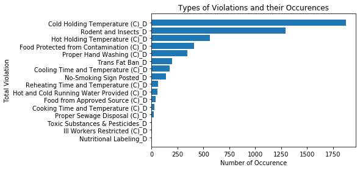

```python
total_pd=total_pd.sort_values(by=['Total'], ascending=True)
plt.barh(y=total_pd.Name, width=total_pd.Total);
plt.ylabel('Total Violation')
plt.xlabel('Number of Occurence')
plt.title('Types of Violations and their Occurences')
#plt.xticks(rotation='vertical')
plt.plot()
```

## 3.2

```python
YearMonthGrp_1=df.groupby(['YearMonth'])['Establishment ID'].count()
df_n=df[df['Violation Flag']==1]
YearMonthGrp_2=df_n.groupby(['YearMonth'])['Establishment ID'].count()
grouped_df_1=pd.DataFrame(YearMonthGrp_1)
grouped_df_2=pd.DataFrame(YearMonthGrp_2)
```

```python
grouped_df_1['Total Violations']= grouped_df_2['Establishment ID']
grouped_df_1.rename(columns = {'Establishment ID':'Total Inspections'}, inplace = True)
grouped_df_1['Percentage']=grouped_df_1['Total Violations']/grouped_df_1['Total Inspections']*100
grouped_df_1['YearMonth']=grouped_df_1.index.values
grouped_df_1.head()
```

| YearMonth | Total Inspections | Total Violations | Percentage | YearMonth |
| --- | --- | --- | --- | --- |
| 2017-09 | 371 | 216 | 58.221024 | 2017-09 |
| 2017-10 | 391 | 196 | 50.127877 | 2017-10 |
| 2017-11 | 382 | 181 | 47.382199 | 2017-11 |
| 2017-12 | 400 | 183 | 45.750000 | 2017-12 |
| 2018-01 | 473 | 205 | 43.340381 | 2018-01 |

```python
grouped_df_1['YearMonth'] = grouped_df_1['YearMonth'].astype(str)
```

```
[]
```

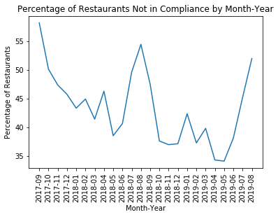

```python
total_pd=total_pd.sort_values(by=['Total'], ascending=True)

plt.plot(grouped_df_1['YearMonth'], grouped_df_1['Percentage']);

plt.ylabel('Percentage of Restaurants')
plt.xlabel('Month-Year')
plt.title('Percentage of Restaurants Not in Compliance by Month-Year')
plt.xticks(rotation = 'vertical')
plt.plot()
```

Here, the percntage of restaurants which are not in compliance is very high at first but decreases, and then again increases around August, 2018. Then there is a spike in January 2019. The rate hits the lowest around May 2019 and then again increases in August 2019.

Here, it is observed that the number of restaurants that violates compliances tends to be higher around the month of August.

## 3.3

```python
import plotly.graph_objs as go
mapbox_access_token = 'pk.eyJ1IjoiamVuaWxrYW4iLCJhIjoiY2p0NXNmODl3MDkzYzQ0cGpuc3FiZThociJ9.ac_UytoTYMET6WNOYpvWnA'
```

```python
class_map_data1 = go.Scattermapbox(
        lon = df[df['Violation Flag']==1]['Longitude'],
        lat = df[df['Violation Flag']==1]['Latitude'],
        text = df['Name'],
        hoverinfo='text',
        name="Not in Compliance",
        mode = 'markers',
        marker = dict(
                    color = 'red',
                    symbol = 'circle',
                    opacity = .6
                )
)

class_map_data2 = go.Scattermapbox(
        lon = df[df['Violation Flag']==0]['Longitude'],
        lat = df[df['Violation Flag']==0]['Latitude'],
        text = df['Name'],
        name="In Compliance",
        hoverinfo='text',
        mode = 'markers',
        marker = dict(
                    color = 'green',
                    symbol = 'circle',
                    opacity = .6
                )
)

class_map_layout = go.Layout(
        title = 'Violation of Compliances in Restaurants',
        mapbox=go.layout.Mapbox(
            accesstoken=mapbox_access_token,
            center=dict(
            lat=39.1,
            lon=282.9426
        ),
            zoom=11
        )
    )

class_map = go.Figure(data=[class_map_data2, class_map_data1], layout=class_map_layout)
class_map.show()
```

[interactive chart not shown]

Below, I have visualized graphs for the top 3 violations to look at how they are scattered in the area.

```python
class_map_data1 = go.Scattermapbox(
        lon = df[(df['Violation Flag']==1) & (df['Hot Holding Temperature (C)_D']==1)]['Longitude'],
        lat = df[(df['Violation Flag']==1) & (df['Hot Holding Temperature (C)_D']==1)]['Latitude'],
        text = df['Name'],
        hoverinfo='text',
        name="Not in Compliance",
        mode = 'markers',
        marker = dict(
                    color = 'red',
                    symbol = 'circle',
                    opacity = .6
                )
)

class_map_layout = go.Layout(
        title = 'Violation of Hot Holding Temperature in Restaurants',
        mapbox=go.layout.Mapbox(
            accesstoken=mapbox_access_token,
            center=dict(
            lat=39.1,
            lon=282.9426
        ),
            zoom=11
        )
    )

class_map = go.Figure(data=[class_map_data1], layout=class_map_layout)
class_map.show()
```

[interactive chart not shown]

Here, for the violation of Hot Holding Temperature, the distribution is somewhat clustered in the populated area, but mostly scattered elsewhere.

```python
class_map_data1 = go.Scattermapbox(
        lon = df[(df['Violation Flag']==1) & (df['Cold Holding Temperature (C)_D']==1)]['Longitude'],
        lat = df[(df['Violation Flag']==1) & (df['Cold Holding Temperature (C)_D']==1)]['Latitude'],
        text = df['Name'],
        hoverinfo='text',
        name="Not in Compliance",
        mode = 'markers',
        marker = dict(
                    color = 'red',
                    symbol = 'circle',
                    opacity = .6
                )
)

class_map_layout = go.Layout(
        title = 'Violation of Cold Holding Temperature in Restaurants',
        mapbox=go.layout.Mapbox(
            accesstoken=mapbox_access_token,
            center=dict(
            lat=39.1,
            lon=282.9426
        ),
            zoom=11
        )
    )

class_map = go.Figure(data=[class_map_data1], layout=class_map_layout)
class_map.show()
```

[interactive chart not shown]

Here, for the violation of Cold Holding Temperature, the distribution is highly clustered in the populated area, but less scattered elsewhere.

```python
class_map_data1 = go.Scattermapbox(
        lon = df[(df['Violation Flag']==1) & (df['Rodent and Insects_D']==1)]['Longitude'],
        lat = df[(df['Violation Flag']==1) & (df['Rodent and Insects_D']==1)]['Latitude'],
        text = df['Name'],
        hoverinfo='text',
        name="Not in Compliance",
        mode = 'markers',
        marker = dict(
                    color = 'red',
                    symbol = 'circle',
                    opacity = .6
                )
)

class_map_layout = go.Layout(
        title = 'Violation of Rodent and Insects in Restaurants',
        mapbox=go.layout.Mapbox(
            accesstoken=mapbox_access_token,
            center=dict(
            lat=39.1,
            lon=282.9426
        ),
            zoom=11
        )
    )

class_map = go.Figure(data=[class_map_data1], layout=class_map_layout)
class_map.show()
```

[interactive chart not shown]

Here, for the violation of Rodent and Insects, the distribution is somewhat clustered in the populated area, and scattered elsewhere.